# The Stroke Prediction Model

Karolina Dyrla-Mularczyk

#This is a report about prediction of stroke. Original data came from Coursera’s Course - “Build and deploy a stroke prediction model using R”.

Stroke is a leading cause of death and disability worldwide, with significant public health implications. Some key facts about stroke:

- **Stroke is the second leading cause of death globally, accounting for approximately 11% of all deaths (WHO).**
- **Around 80% of strokes are preventable through lifestyle modifications such as healthy diet, regular exercise, and avoiding tobacco use.**
- **High blood pressure is one of the most important modifiable risk factor for stroke.**
- **Early recognition of stroke symptoms and prompt medical intervention can significantly improve outcomes and reduce disability.**
- **Hence the need to identify risk factors and assess their importance in the stroke prediction model.This is important both from the perspective of the healthcare sector and from the patient’s perspective.**

The dataset came from Kaggle via Coursera and includes information on patients such as:

- age,
- BMI,
- average glucose level,
- heart disease,
- hypertension,
- and more demographic details

The dataset consists of 5110 observations, with 249 patients experiencing a stroke. This imbalance indicates that only 4.87% of the total observations involve stroke occurrences.

A few general informations about dataset:

```r
dim(stroke)
```

```
## [1] 5110   12
```

```r
head(stroke)
```

```
##      id gender age hypertension heart_disease ever_married     work_type
## 1  9046   Male  67            0             1          Yes       Private
## 2 51676 Female  61            0             0          Yes Self-employed
## 3 31112   Male  80            0             1          Yes       Private
## 4 60182 Female  49            0             0          Yes       Private
## 5  1665 Female  79            1             0          Yes Self-employed
## 6 56669   Male  81            0             0          Yes       Private
##   Residence_type avg_glucose_level   bmi  smoking_status stroke
## 1          Urban            228.69 36.60 formerly smoked      1
## 2          Rural            202.21 28.89    never smoked      1
## 3          Rural            105.92 32.50    never smoked      1
## 4          Urban            171.23 34.40          smokes      1
## 5          Rural            174.12 24.00    never smoked      1
## 6          Urban            186.21 29.00 formerly smoked      1
```

```r
str(stroke)
```

```
## 'data.frame':    5110 obs. of  12 variables:
##  $ id               : int  9046 51676 31112 60182 1665 56669 53882 10434 27419 60491 ...
##  $ gender           : chr  "Male" "Female" "Male" "Female" ...
##  $ age              : num  67 61 80 49 79 81 74 69 59 78 ...
##  $ hypertension     : int  0 0 0 0 1 0 1 0 0 0 ...
##  $ heart_disease    : int  1 0 1 0 0 0 1 0 0 0 ...
##  $ ever_married     : chr  "Yes" "Yes" "Yes" "Yes" ...
##  $ work_type        : chr  "Private" "Self-employed" "Private" "Private" ...
##  $ Residence_type   : chr  "Urban" "Rural" "Rural" "Urban" ...
##  $ avg_glucose_level: num  229 202 106 171 174 ...
##  $ bmi              : num  36.6 28.9 32.5 34.4 24 ...
##  $ smoking_status   : chr  "formerly smoked" "never smoked" "never smoked" "smokes" ...
##  $ stroke           : int  1 1 1 1 1 1 1 1 1 1 ...
```

```r
names(stroke)
```

```
##  [1] "id"                "gender"            "age"
##  [4] "hypertension"      "heart_disease"     "ever_married"
##  [7] "work_type"         "Residence_type"    "avg_glucose_level"
## [10] "bmi"               "smoking_status"    "stroke"
```

```r
summary(stroke)
```

```
##        id           gender               age         hypertension
##  Min.   :   67   Length:5110        Min.   : 0.08   Min.   :0.00000
##  1st Qu.:17741   Class :character   1st Qu.:25.00   1st Qu.:0.00000
##  Median :36932   Mode  :character   Median :45.00   Median :0.00000
##  Mean   :36518                      Mean   :43.23   Mean   :0.09746
##  3rd Qu.:54682                      3rd Qu.:61.00   3rd Qu.:0.00000
##  Max.   :72940                      Max.   :82.00   Max.   :1.00000
##  heart_disease     ever_married        work_type         Residence_type
##  Min.   :0.00000   Length:5110        Length:5110        Length:5110
##  1st Qu.:0.00000   Class :character   Class :character   Class :character
##  Median :0.00000   Mode  :character   Mode  :character   Mode  :character
##  Mean   :0.05401
##  3rd Qu.:0.00000
##  Max.   :1.00000
##  avg_glucose_level      bmi        smoking_status         stroke
##  Min.   : 55.12    Min.   :10.30   Length:5110        Min.   :0.00000
##  1st Qu.: 77.25    1st Qu.:23.80   Class :character   1st Qu.:0.00000
##  Median : 91.89    Median :28.40   Mode  :character   Median :0.00000
##  Mean   :106.15    Mean   :28.89                      Mean   :0.04873
##  3rd Qu.:114.09    3rd Qu.:32.80                      3rd Qu.:0.00000
##  Max.   :271.74    Max.   :97.60                      Max.   :1.00000
```

```r
skim(stroke)
```

Data summary

| Name | stroke |
| --- | --- |
| Number of rows | 5110 |
| Number of columns | 12 |
| _______________________ |  |
| Column type frequency: |  |
| character | 5 |
| numeric | 7 |
| ________________________ |  |
| Group variables | None |

**Variable type: character**

| skim_variable | n_missing | complete_rate | min | max | empty | n_unique | whitespace |
| --- | --- | --- | --- | --- | --- | --- | --- |
| gender | 0 | 1 | 4 | 6 | 0 | 3 | 0 |
| ever_married | 0 | 1 | 2 | 3 | 0 | 2 | 0 |
| work_type | 0 | 1 | 7 | 13 | 0 | 5 | 0 |
| Residence_type | 0 | 1 | 5 | 5 | 0 | 2 | 0 |
| smoking_status | 0 | 1 | 6 | 15 | 0 | 4 | 0 |

**Variable type: numeric**

| skim_variable | n_missing | complete_rate | mean | sd | p0 | p25 | p50 | p75 | p100 | hist |
| --- | --- | --- | --- | --- | --- | --- | --- | --- | --- | --- |
| id | 0 | 1 | 36517.83 | 21161.72 | 67.00 | 17741.25 | 36932.00 | 54682.00 | 72940.00 | ▇▇▇▇▇ |
| age | 0 | 1 | 43.23 | 22.61 | 0.08 | 25.00 | 45.00 | 61.00 | 82.00 | ▅▆▇▇▆ |
| hypertension | 0 | 1 | 0.10 | 0.30 | 0.00 | 0.00 | 0.00 | 0.00 | 1.00 | ▇▁▁▁▁ |
| heart_disease | 0 | 1 | 0.05 | 0.23 | 0.00 | 0.00 | 0.00 | 0.00 | 1.00 | ▇▁▁▁▁ |
| avg_glucose_level | 0 | 1 | 106.15 | 45.28 | 55.12 | 77.24 | 91.88 | 114.09 | 271.74 | ▇▃▁▁▁ |
| bmi | 0 | 1 | 28.89 | 7.70 | 10.30 | 23.80 | 28.40 | 32.80 | 97.60 | ▇▇▁▁▁ |
| stroke | 0 | 1 | 0.05 | 0.22 | 0.00 | 0.00 | 0.00 | 0.00 | 1.00 | ▇▁▁▁▁ |

Missing values were found in the “bmi” column. It was decided to enter the average of all BMI measurements in the missing fields and round it to two decimal places.

The charts below show the distribution of demographic variables: gender, place of residence and place of work.

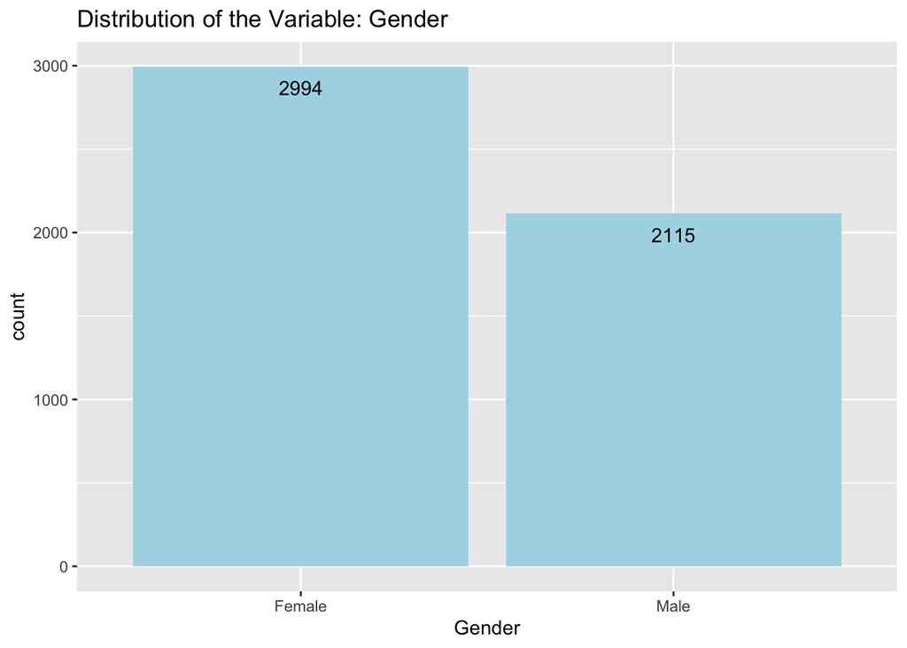

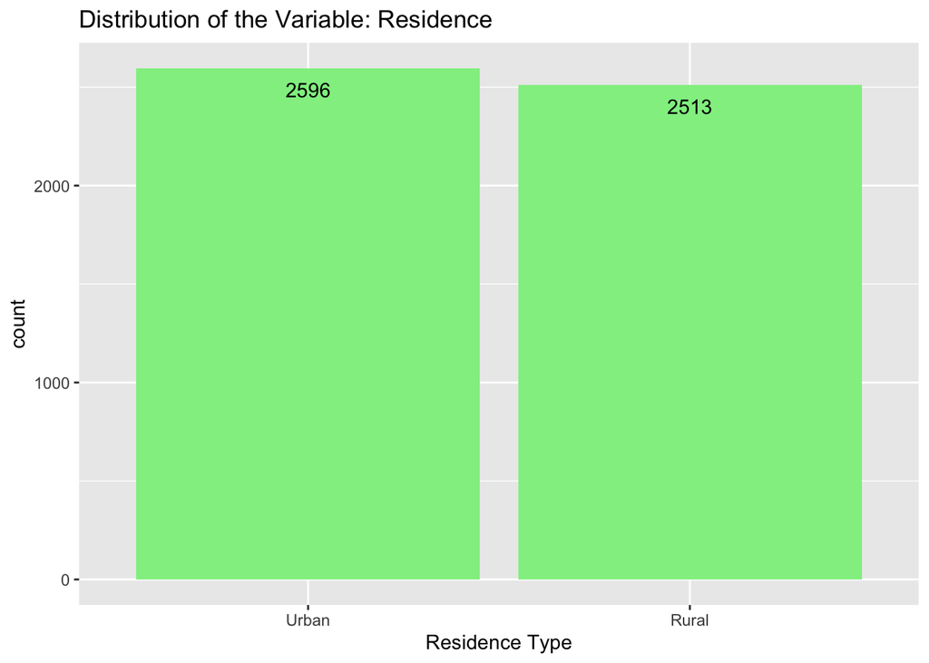

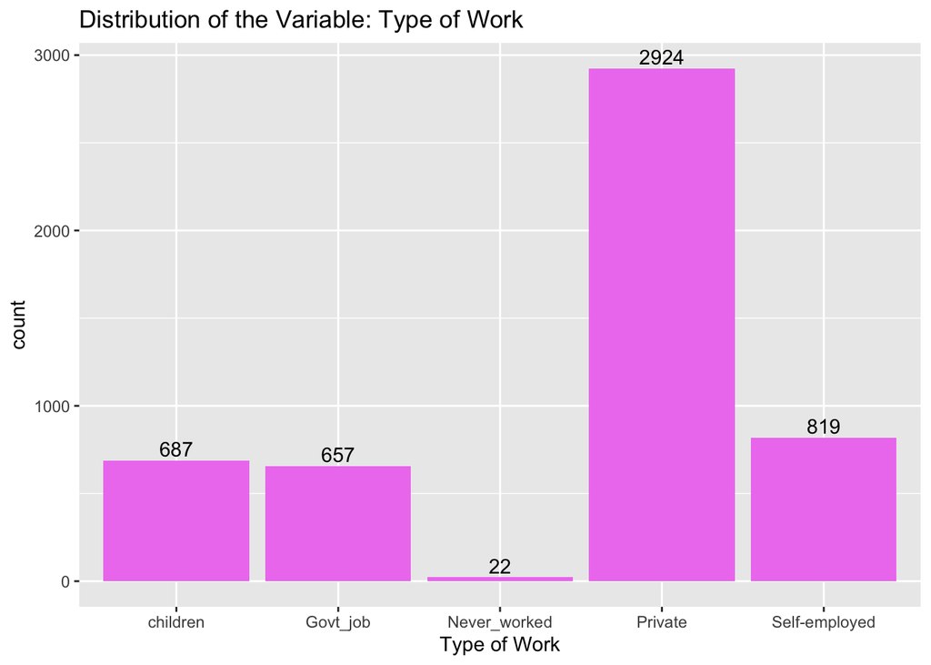

The charts below show the distribution of health related variables: hypertension, heart disease, smoking status.

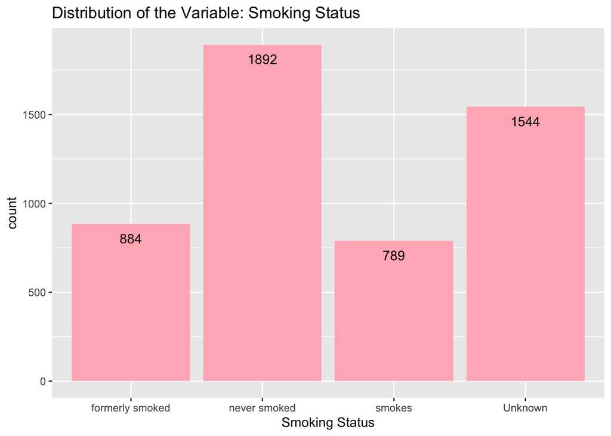

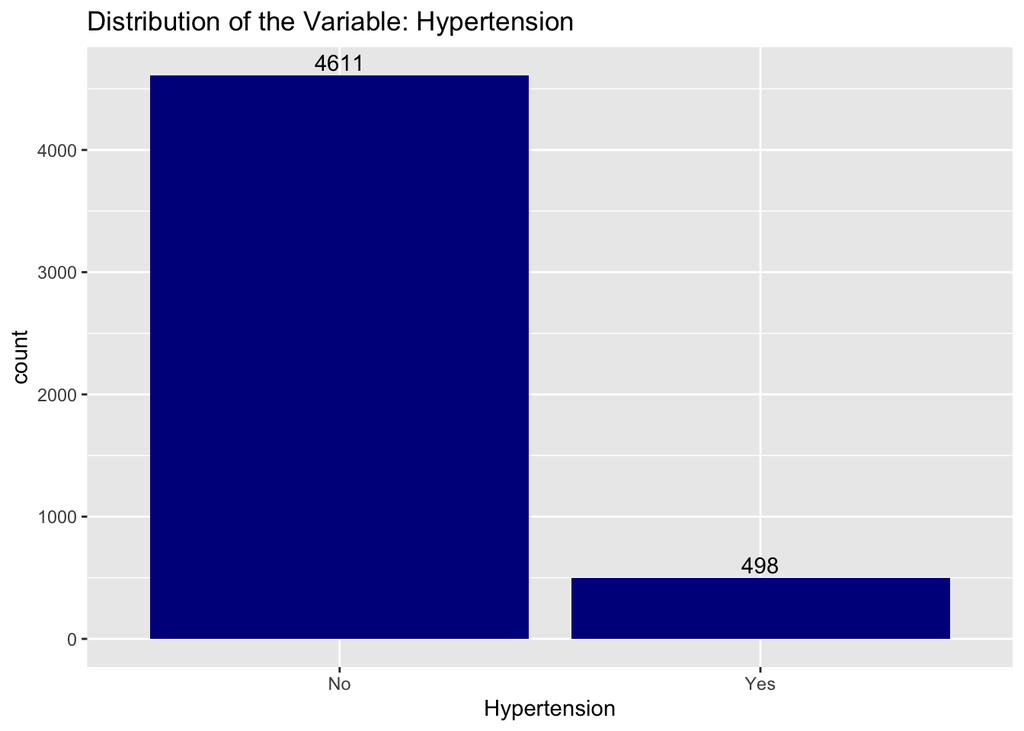

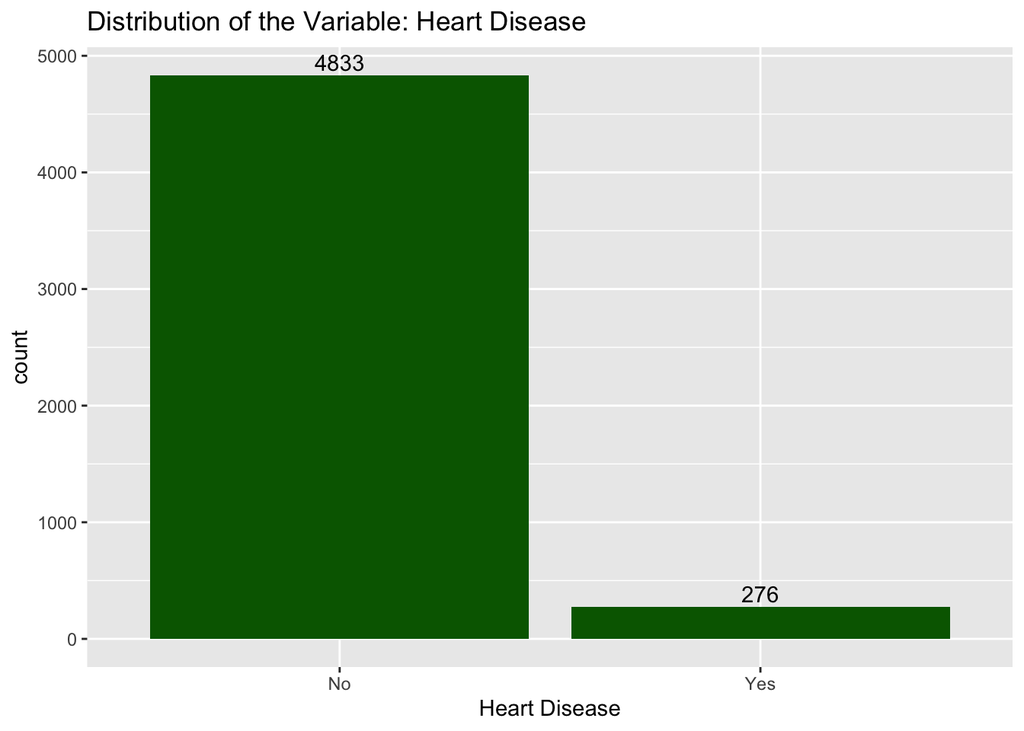

BMI data was organized according to the “BMI Classification Percentile And Cut Off Points” classification. The BMI criteria distributed in the study group are presented in the chart below.

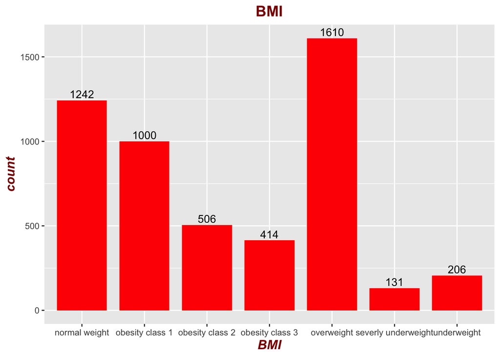

> “In 2022, 2.5 billion adults (18 years and older) were overweight. Of these, 890 million were living with obesity. In 2022, 43% of adults aged 18 years and over were overweight and 16% were living with obesity.

The chart below shows the distribution of patients with and without stroke depending on their smoking status.

|  | Patients without stroke | Patients with stroke |
| --- | --- | --- |
| formerly smoked | 814 | 70 |
| never smoked | 1802 | 90 |
| smokes | 747 | 42 |
| Unknown | 1497 | 47 |